# Predicting Income Level

# Preface

I will develop classification models to classify census data into “>50K” income bracket or “<=50K” income bracket using several approaches and compare their performance on the “Census Income” dataset from UCI ML. The description for this dataset also presents performance (prediction accuracy) observed by the dataset providers using variety of modeling techniques – this supplies a context for the errors of the models we will develop here.

Please note that the original data has been split up into training and test subsets, but there doesn’t seem to be anything particular about that split, so I pooled those two datasets together and split them into training and test as necessary.

```r
#read data
data.train <-  read.table("CensusIncome/adult.data", header = F, sep = ",", na.strings = c(" ?"), col.names=c("age", "workclass", "fnlwgt", "ed", "ed-num", "marital", "occ", "rs", "race", "sex", "cgain", "closs", "hours", "ncntry", "inclvl"))

data.test <-  read.table("CensusIncome/adult.test", header = F, sep = ",", na.strings = c(" ?"), col.names=c("age", "workclass", "fnlwgt", "ed", "ed-num", "marital", "occ", "rs", "race", "sex", "cgain", "closs", "hours", "ncntry", "inclvl"))

#remove "." income level
data.test$inclvl <- gsub("K.", "K", data.test$inclvl)

#pool data
data <- rbind(data.train, data.test)
rm(data.test)
rm(data.train)

#remove NAs
data <- na.omit(data)

#remove "final weight" variable
data <- data[,-grep("fnlwgt",colnames(data))]

#discretize native country to US/non-US
data$ncntry <- as.factor(ifelse(data$ncntry==" United-States","US","non-US"))

#collaspe High school and below into 1 group
levels(data$ed) <- c("HS&below","HS&below","HS&below","HS&below","HS&below","HS&below","HS&below","Assoc-acdm","Assoc-voc","Bachelors","Doctorate","HS&below","Masters","HS&below","Prof-school","Some-college")

#log transform cgain and closs for better spread, +0.01 to handle log0
data$cgain <- log(data$cgain+.01)
data$closs <- log(data$closs+.01)

#create working datasets
data.1000 <- data[sample(1:nrow(data), 1000),]
```

Attribute called “final weight” in the dataset description represents demographic weighting of these observations; this was disregarded for the purposes of this analysis.

Additionally, several attributes in this dataset are categorical variables with more than two levels (e.g. native country, occupation, etc.).

Lastly, the size of this dataset can make some of the modeling techniques run slowly. Some models are run on a subset of data and will be noted.

# Part 1: univariate and unsupervised analysis

## Graphical and numerical summaries: e.g. histograms of continuous attributes, contingency tables of categorical variables, scatterplots of continuous attributes with some of the categorical variables indicated by color/symbol shape, etc.

```r
library(GGally)
library(ggplot2)
#str(data$inclvl)#Factor w/ 2 levels " <=50K"," >50K": 1 1 1 1 1 1 1 2 2 2
#ggpairs(data.w, aes(colour = inclvl))

summary(data)
```

```
##       age                    workclass                ed
##  Min.   :17.00    Private         :33307   HS&below    :20444
##  1st Qu.:28.00    Self-emp-not-inc: 3796   Some-college: 9899
##  Median :37.00    Local-gov       : 3100   Bachelors   : 7570
##  Mean   :38.55    State-gov       : 1946   Masters     : 2514
##  3rd Qu.:47.00    Self-emp-inc    : 1646   Assoc-voc   : 1959
##  Max.   :90.00    Federal-gov     : 1406   Assoc-acdm  : 1507
##                  (Other)          :   21   (Other)     : 1329
##      ed.num                        marital                    occ
##  Min.   : 1.00    Divorced             : 6297    Craft-repair   : 6020
##  1st Qu.: 9.00    Married-AF-spouse    :   32    Prof-specialty : 6008
##  Median :10.00    Married-civ-spouse   :21055    Exec-managerial: 5984
##  Mean   :10.12    Married-spouse-absent:  552    Adm-clerical   : 5540
##  3rd Qu.:13.00    Never-married        :14598    Sales          : 5408
##  Max.   :16.00    Separated            : 1411    Other-service  : 4808
##                   Widowed              : 1277   (Other)         :11454
##                rs                         race            sex
##   Husband       :18666    Amer-Indian-Eskimo:  435    Female:14695
##   Not-in-family :11702    Asian-Pac-Islander: 1303    Male  :30527
##   Other-relative: 1349    Black             : 4228
##   Own-child     : 6626    Other             :  353
##   Unmarried     : 4788    White             :38903
##   Wife          : 2091
##
##      cgain            closs            hours          ncntry
##  Min.   :-4.605   Min.   :-4.605   Min.   : 1.00   non-US: 3930
##  1st Qu.:-4.605   1st Qu.:-4.605   1st Qu.:40.00   US    :41292
##  Median :-4.605   Median :-4.605   Median :40.00
##  Mean   :-3.478   Mean   :-4.032   Mean   :40.94
##  3rd Qu.:-4.605   3rd Qu.:-4.605   3rd Qu.:45.00
##  Max.   :11.513   Max.   : 8.379   Max.   :99.00
##
##     inclvl
##   <=50K:34014
##   >50K :11208
##
##
##
##
##
```

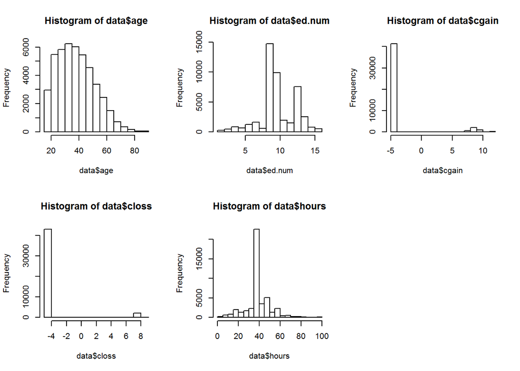

```r
#histograms
old.par <- par(mfrow=c(2,3))
hist(data$age)
hist(data$ed.num)
hist(data$cgain)
hist(data$closs)
hist(data$hours)
par(old.par)
```

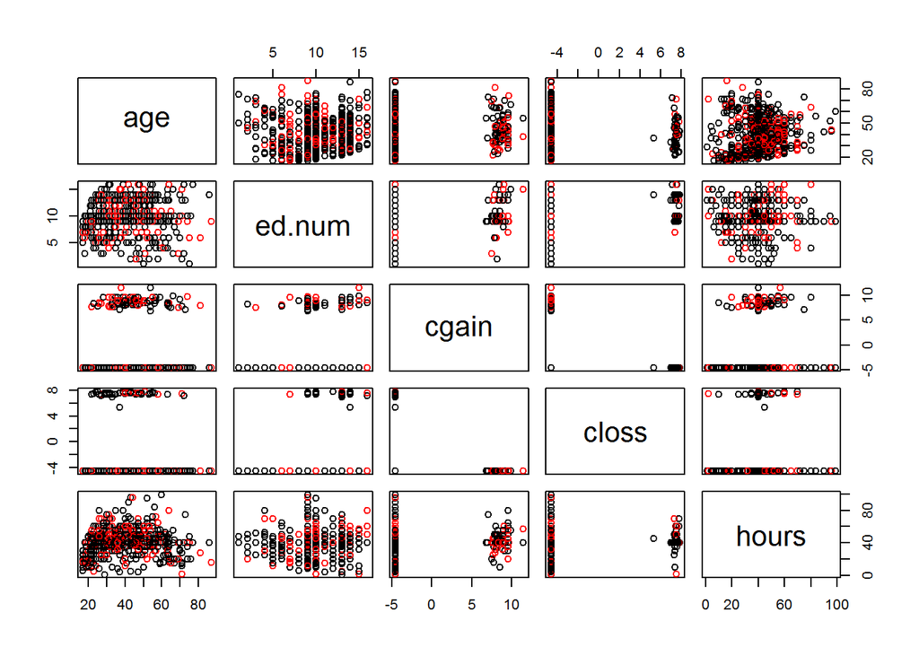

```r
#scatterplots coloured by inclvl
pairs(~age+ed.num+cgain+closs+hours, data = data.1000, col = data$inclvl)
```

[figure not shown]

```r
#scatterplots coloured by catgorical attributes
old.par <- par(mfrow=c(2,2))
plot(data.1000$age, data.1000$hours, col = data$inclvl, main = "age against hours grouped by inclvl")
plot(data.1000$age, data.1000$hours, col = data$sex, main = "age against hours grouped by sex")
plot(data.1000$age, data.1000$hours, col = data$race, main = "age against hours grouped by age")
plot(data.1000$age, data.1000$hours, col = data$ncntry, main = "age against hours grouped by race")
```

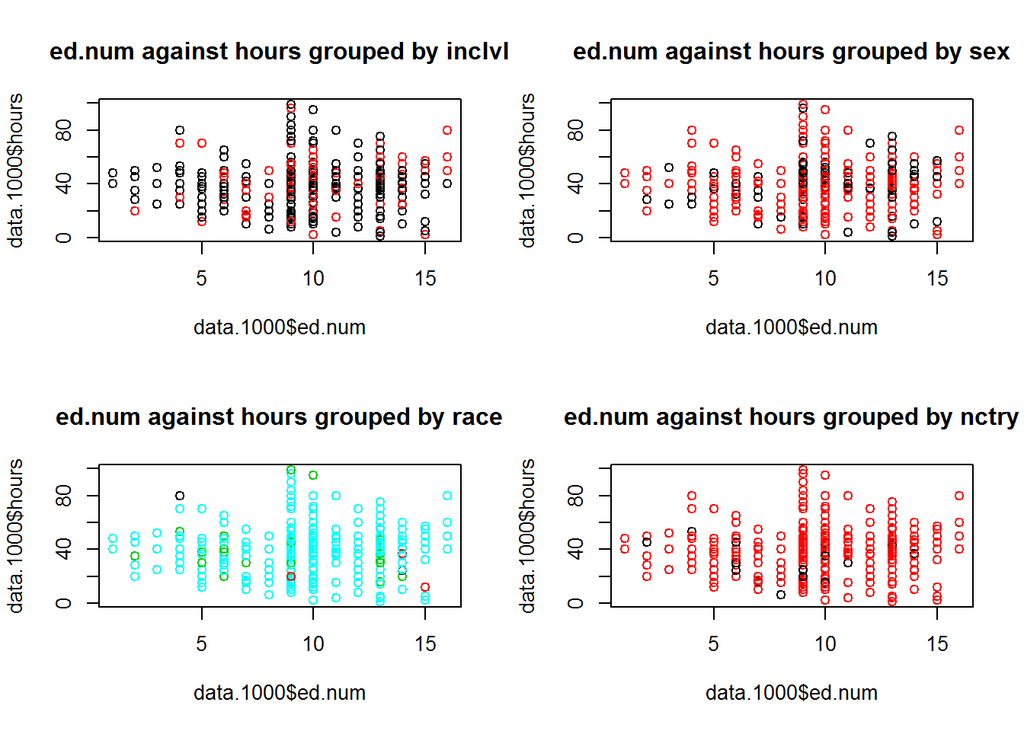

```r
par(old.par)

old.par <- par(mfrow=c(2,2))
plot(data.1000$ed.num, data.1000$hours, col = data$inclvl, main = "ed.num against hours grouped by inclvl")
plot(data.1000$ed.num, data.1000$hours, col = data$sex, main = "ed.num against hours grouped by sex")
plot(data.1000$ed.num, data.1000$hours, col = data$race, main = "ed.num against hours grouped by race")
plot(data.1000$ed.num, data.1000$hours, col = data$ncntry, main = "ed.num against hours grouped by nctry")
```

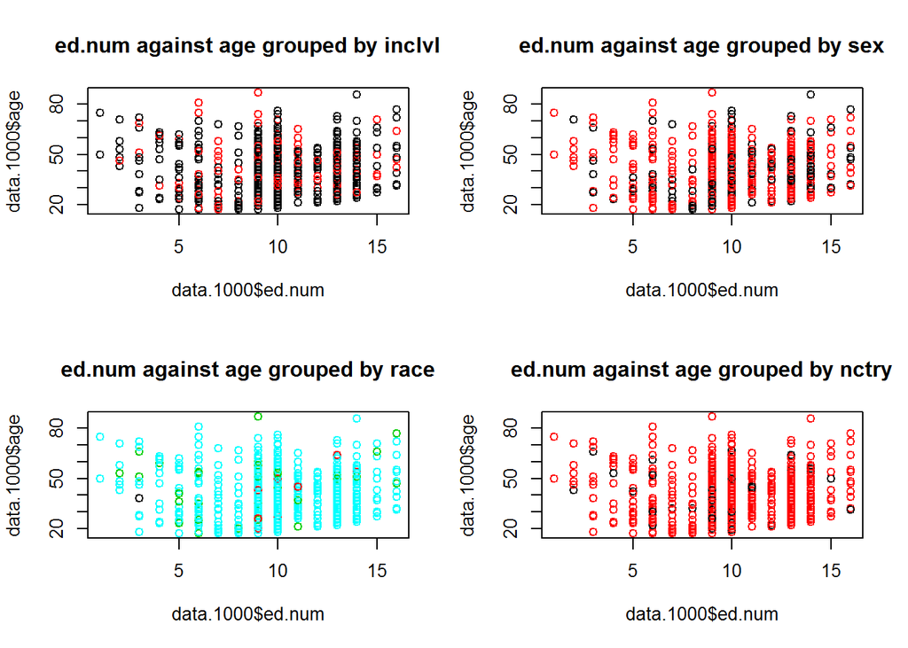

```r
par(old.par)

old.par <- par(mfrow=c(2,2))
plot(data.1000$ed.num, data.1000$age, col = data$inclvl, main = "ed.num against age grouped by inclvl")
plot(data.1000$ed.num, data.1000$age, col = data$sex, main = "ed.num against age grouped by sex")
plot(data.1000$ed.num, data.1000$age, col = data$race, main = "ed.num against age grouped by race")
plot(data.1000$ed.num, data.1000$age, col = data$ncntry, main = "ed.num against age grouped by nctry")
```

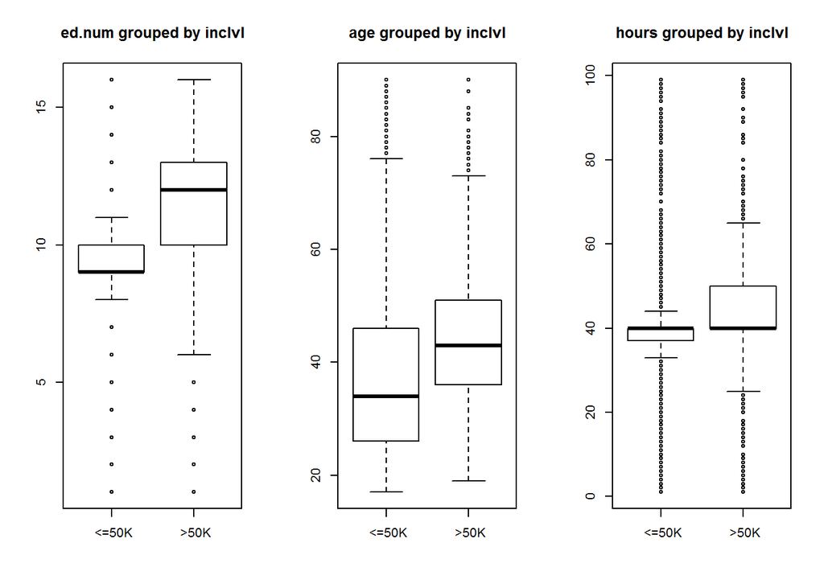

```r
par(old.par)

#boxplots of continuous variables by inclvl
old.par <- par(mfrow=c(1,3))
boxplot(ed.num~inclvl, data = data, main = "ed.num grouped by inclvl")
boxplot(age~inclvl, data = data, main = "age grouped by inclvl")
boxplot(hours~inclvl, data = data, main = "hours grouped by inclvl")
```

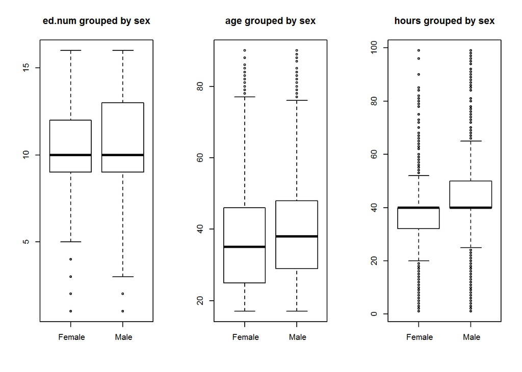

```r
par(old.par)

#boxplots of continuous variables by sex
old.par <- par(mfrow=c(1,3))
boxplot(ed.num~sex, data = data, main = "ed.num grouped by sex")
boxplot(age~sex, data = data, main = "age grouped by sex")
boxplot(hours~sex, data = data, main = "hours grouped by sex")
```

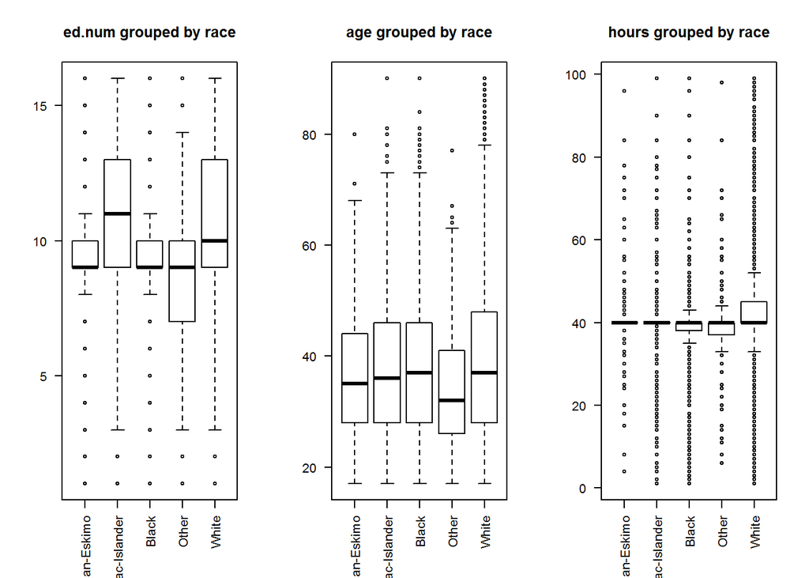

```r
par(old.par)

#boxplots of continuous variables by race
old.par <- par(mfrow=c(1,3))
boxplot(ed.num~race, data = data, main = "ed.num grouped by race",las=2)
boxplot(age~race, data = data, main = "age grouped by race",las=2)
boxplot(hours~race, data = data, main = "hours grouped by race",las=2)
```

```r
par(old.par)

#probability tables of categorical variables
sum(table(data$ed, data$inclvl)[1,])
```

```
## [1] 20444
```

```r
table(data$ed, data$inclvl)/sum(table(data$ed, data$inclvl))
```

```
##
##                      <=50K        >50K
##   HS&below     0.391181283 0.060899562
##   Assoc-acdm   0.024523462 0.008801026
##   Assoc-voc    0.032174605 0.011145018
##   Bachelors    0.097120870 0.070275530
##   Doctorate    0.003206404 0.008823139
##   Masters      0.024788820 0.030803591
##   Prof-school  0.004267834 0.013090973
##   Some-college 0.174892751 0.044005130
```

```r
table(data$sex, data$inclvl)/sum(table(data$sex, data$inclvl))
```

```
##
##                <=50K       >50K
##    Female 0.28804564 0.03690682
##    Male   0.46411039 0.21093715
```

```r
table(data$race, data$inclvl)/sum(table(data$race, data$inclvl))
```

```
##
##                              <=50K         >50K
##    Amer-Indian-Eskimo 0.0084472160 0.0011719959
##    Asian-Pac-Islander 0.0206536641 0.0081597453
##    Black              0.0816859051 0.0118084118
##    Other              0.0068108443 0.0009950909
##    White              0.6345584008 0.2257087258
```

```r
table(data$marital, data$inclvl)/sum(table(data$marital, data$inclvl))
```

```
##
##                                 <=50K         >50K
##    Divorced              0.1247622838 0.0144841007
##    Married-AF-spouse     0.0003980364 0.0003095838
##    Married-civ-spouse    0.2541019858 0.2114899828
##    Married-spouse-absent 0.0110123391 0.0011941091
##    Never-married         0.3073061784 0.0155013047
##    Separated             0.0290124276 0.0021891999
##    Widowed               0.0255627792 0.0026756888
```

> This suggests that if there is some kind of correlation between race and income, ed.num could be a confounding factor.

## Principal components analysis of this data (scaled, and converted categorical data into binary data). Plot observations in the space of the first few principal components with subjects’ gender and/or categorized income indicated by color/shape of the symbol.

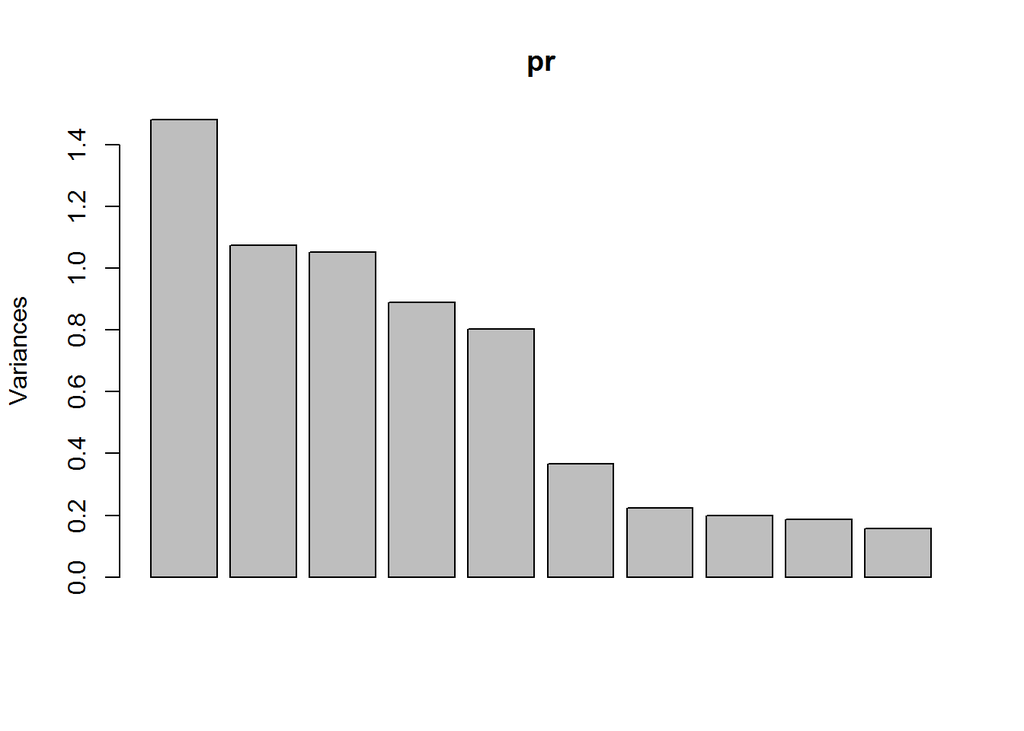

```r
#make binary variables
data.bin <- model.matrix(~.,data)

#scale continuous variables
data.bin[,c("age","hours","cgain","closs","ed.num")] <- scale(data.bin[,c("age","hours","cgain","closs","ed.num")])

#PC model
pr <- prcomp(data.bin[,c(-1,-51,-46)]) #col 1 is the y intercept. col 51 represents inclvl, 46 represents sex
plot(pr)
```

```r
#top 5 contributors to PCs 1:4
sort(abs(pr$rotation[,1]),decreasing = T)[1:5]
```

```
##                   age                 hours                ed.num
##             0.5004454             0.4791521             0.4553470
##                 cgain marital Never-married
##             0.3805509             0.1962877
```

```r
sort(abs(pr$rotation[,2]),decreasing = T)[1:5]
```

```
##                 closs                ed.num                   age
##             0.5636622             0.5276364             0.4614007
##                 cgain marital Never-married
##             0.3487686             0.1380671
```

```r
sort(abs(pr$rotation[,3]),decreasing = T)[1:5]
```

```
##                 closs                 cgain                   age
##             0.5704066             0.4790038             0.4497302
##                ed.num marital Never-married
##             0.4321175             0.1482880
```

```r
sort(abs(pr$rotation[,4]),decreasing = T)[1:5]
```

```
##     hours     cgain     closs       age    ed.num
## 0.8194824 0.3405940 0.3279629 0.2221439 0.2086567
```

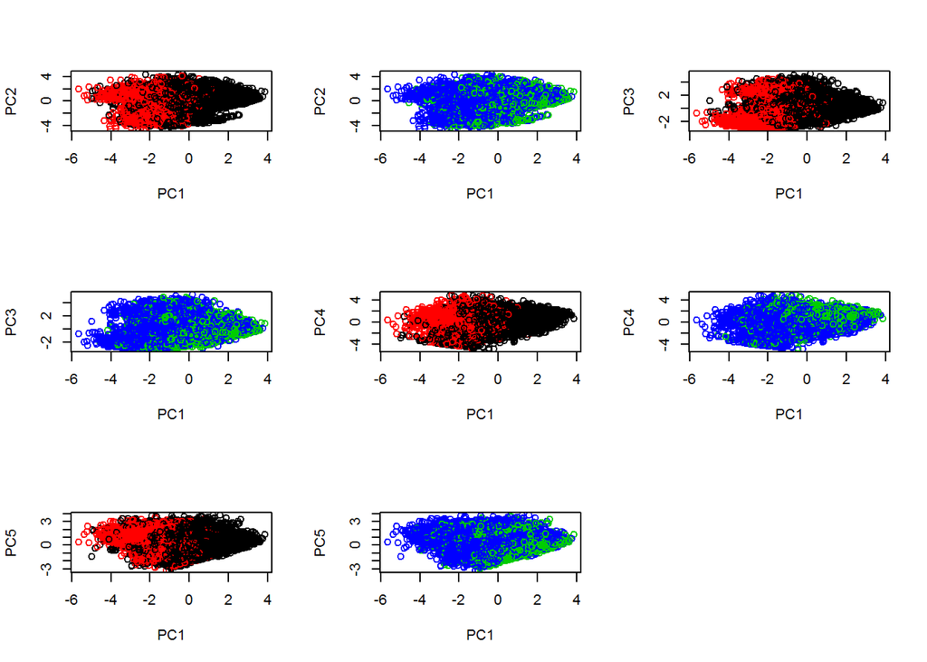

```r
#plots of observations against top few PCs
old.par <- par(mfrow=c(3,3))
plot(pr$x[,1:2],col=data$inclvl) #black = 1 = "<=50K", red = 2 = ">50K"
plot(pr$x[,1:2],col=c(3,4)[data$sex]) #green = 1 = "Female", blue = 2 = "Male"
plot(pr$x[,c(1,3)],col=data$inclvl)
plot(pr$x[,c(1,3)],col=c(3,4)[data$sex])
plot(pr$x[,c(1,4)],col=data$inclvl)
plot(pr$x[,c(1,4)],col=c(3,4)[data$sex])
plot(pr$x[,c(1,5)],col=data$inclvl)
plot(pr$x[,c(1,5)],col=c(3,4)[data$sex])
par(old.par)
```

> Yes scaled the continuous variables before performing PCA, since PCA is reliant on the covariance matrix, which woud be very influenced by variables with extremely high variance or absolute values.

> I represented a multilevel categorical variable into a collection of (N-1) dummy binaries and then perform PCA on this data.

> The scree plot shows that most of the variation in the data can be expained by PCs 1:5. Looking at the top contributing predictors to PCs1:5, the predictors that matter are the continuous variables, especially age, hours, ed.num. The binary variables do not feature much, except the marital status of never married.

> Plotting the observations against the top PCs shows that Income level can be explained by PC1. <50K earners are positive scores on PC1, and >50K earners are negative scores on PC1.

> PC2, 3 and 5 do not manage to tease out any other clusters in the data, as we do not see the cloud of data points breaking in the direction of the y axis. They are not able to cluster well the data by sex, as can be seen by the overlap between blue and green points.

> PC 4 (and 1) might be the best at clustering the data by sex as can be seen by the green (female) points gathering towards the top right corner of the cloud. PC4 and 1 also seem to cluster the red points towards the top left corner.

## Univariate assessment of associations between outcome and each of the attributes (e.g. t-test or logistic regression for continuous attributes, contingency tables/Fisher exact test/$\chi^2$ test for categorical attributes).

```r
#t-tests for continuous predictors on full dataset
t.test(data$age~data$inclvl)
```

```
##
##  Welch Two Sample t-test
##
## data:  data$age by data$inclvl
## t = -59.35, df = 24884, p-value < 2.2e-16
## alternative hypothesis: true difference in means is not equal to 0
## 95 percent confidence interval:
##  -7.496295 -7.016986
## sample estimates:
## mean in group  <=50K  mean in group  >50K
##             36.74943             44.00607
```

```r
t.test(data$hours~data$inclvl)
```

```
##
##  Welch Two Sample t-test
##
## data:  data$hours by data$inclvl
## t = -52.26, df = 20994, p-value < 2.2e-16
## alternative hypothesis: true difference in means is not equal to 0
## 95 percent confidence interval:
##  -6.555447 -6.081484
## sample estimates:
## mean in group  <=50K  mean in group  >50K
##             39.37202             45.69049
```

```r
t.test(data$ed.num~data$inclvl)
```

```
##
##  Welch Two Sample t-test
##
## data:  data$ed.num by data$inclvl
## t = -75.89, df = 19494, p-value < 2.2e-16
## alternative hypothesis: true difference in means is not equal to 0
## 95 percent confidence interval:
##  -2.018554 -1.916909
## sample estimates:
## mean in group  <=50K  mean in group  >50K
##              9.63077             11.59850
```

```r
t.test(data$cgain~data$inclvl)
```

```
##
##  Welch Two Sample t-test
##
## data:  data$cgain by data$inclvl
## t = -43.643, df = 12678, p-value < 2.2e-16
## alternative hypothesis: true difference in means is not equal to 0
## 95 percent confidence interval:
##  -2.537068 -2.318969
## sample estimates:
## mean in group  <=50K  mean in group  >50K
##            -4.080247            -1.652228
```

```r
t.test(data$closs~data$inclvl)
```

```
##
##  Welch Two Sample t-test
##
## data:  data$closs by data$inclvl
## t = -22.895, df = 13711, p-value < 2.2e-16
## alternative hypothesis: true difference in means is not equal to 0
## 95 percent confidence interval:
##  -0.8953670 -0.7541464
## sample estimates:
## mean in group  <=50K  mean in group  >50K
##            -4.236193            -3.411436
```

```r
#chisq-tests for categorical predictors on full dataset
chisq.test(table(data$ed, data$inclvl))
```

```
##
##  Pearson's Chi-squared test
##
## data:  table(data$ed, data$inclvl)
## X-squared = 5756.5, df = 7, p-value < 2.2e-16
```

```r
chisq.test(table(data$sex, data$inclvl))
```

```
##
##  Pearson's Chi-squared test with Yates' continuity correction
##
## data:  table(data$sex, data$inclvl)
## X-squared = 2104.1, df = 1, p-value < 2.2e-16
```

```r
chisq.test(table(data$race, data$inclvl))
```

```
##
##  Pearson's Chi-squared test
##
## data:  table(data$race, data$inclvl)
## X-squared = 452.3, df = 4, p-value < 2.2e-16
```

```r
chisq.test(table(data$marital, data$inclvl))
```

```
##
##  Pearson's Chi-squared test
##
## data:  table(data$marital, data$inclvl)
## X-squared = 9109.2, df = 6, p-value < 2.2e-16
```

```r
chisq.test(table(data$occ, data$inclvl))
```

```
##
##  Pearson's Chi-squared test
##
## data:  table(data$occ, data$inclvl)
## X-squared = 5415.1, df = 13, p-value < 2.2e-16
```

```r
chisq.test(table(data$workclass, data$inclvl))
```

```
##
##  Pearson's Chi-squared test
##
## data:  table(data$workclass, data$inclvl)
## X-squared = NaN, df = 7, p-value = NA
```

```r
chisq.test(table(data$rs, data$inclvl))
```

```
##
##  Pearson's Chi-squared test
##
## data:  table(data$rs, data$inclvl)
## X-squared = 9357, df = 5, p-value < 2.2e-16
```

```r
chisq.test(table(data$ncntry, data$inclvl))
```

```
##
##  Pearson's Chi-squared test with Yates' continuity correction
##
## data:  table(data$ncntry, data$inclvl)
## X-squared = 68.157, df = 1, p-value < 2.2e-16
```

```r
#t-tests for continuous predictors on 1000 obs dataset
t.test(data.1000$age~data.1000$inclvl)
```

```
##
##  Welch Two Sample t-test
##
## data:  data.1000$age by data.1000$inclvl
## t = -8.0154, df = 561.14, p-value = 6.401e-15
## alternative hypothesis: true difference in means is not equal to 0
## 95 percent confidence interval:
##  -8.093137 -4.907344
## sample estimates:
## mean in group  <=50K  mean in group  >50K
##             37.47444             43.97468
```

```r
t.test(data.1000$hours~data.1000$inclvl)
```

```
##
##  Welch Two Sample t-test
##
## data:  data.1000$hours by data.1000$inclvl
## t = -5.2427, df = 439.72, p-value = 2.463e-07
## alternative hypothesis: true difference in means is not equal to 0
## 95 percent confidence interval:
##  -5.930008 -2.696213
## sample estimates:
## mean in group  <=50K  mean in group  >50K
##             39.66579             43.97890
```

```r
t.test(data.1000$ed.num~data.1000$inclvl)
```

```
##
##  Welch Two Sample t-test
##
## data:  data.1000$ed.num by data.1000$inclvl
## t = -11.623, df = 426.46, p-value < 2.2e-16
## alternative hypothesis: true difference in means is not equal to 0
## 95 percent confidence interval:
##  -2.340551 -1.663442
## sample estimates:
## mean in group  <=50K  mean in group  >50K
##             9.546527            11.548523
```

```r
t.test(data.1000$cgain~data.1000$inclvl)
```

```
##
##  Welch Two Sample t-test
##
## data:  data.1000$cgain by data.1000$inclvl
## t = -6.9798, df = 266.16, p-value = 2.35e-11
## alternative hypothesis: true difference in means is not equal to 0
## 95 percent confidence interval:
##  -3.560603 -1.993775
## sample estimates:
## mean in group  <=50K  mean in group  >50K
##            -4.012181            -1.234992
```

```r
t.test(data.1000$closs~data.1000$inclvl)
```

```
##
##  Welch Two Sample t-test
##
## data:  data.1000$closs by data.1000$inclvl
## t = -4.2597, df = 277.73, p-value = 2.806e-05
## alternative hypothesis: true difference in means is not equal to 0
## 95 percent confidence interval:
##  -1.7385834 -0.6395592
## sample estimates:
## mean in group  <=50K  mean in group  >50K
##            -4.198039            -3.008967
```

```r
#chisq-tests for categorical predictors on 1000 obs dataset
chisq.test(table(data.1000$ed, data.1000$inclvl))
```

```
##
##  Pearson's Chi-squared test
##
## data:  table(data.1000$ed, data.1000$inclvl)
## X-squared = 124.13, df = 7, p-value < 2.2e-16
```

```r
chisq.test(table(data.1000$sex, data.1000$inclvl))
```

```
##
##  Pearson's Chi-squared test with Yates' continuity correction
##
## data:  table(data.1000$sex, data.1000$inclvl)
## X-squared = 37.553, df = 1, p-value = 8.895e-10
```

```r
chisq.test(table(data.1000$race, data.1000$inclvl))
```

```
##
##  Pearson's Chi-squared test
##
## data:  table(data.1000$race, data.1000$inclvl)
## X-squared = 22.776, df = 4, p-value = 0.0001403
```

```r
chisq.test(table(data.1000$marital, data.1000$inclvl))
```

```
##
##  Pearson's Chi-squared test
##
## data:  table(data.1000$marital, data.1000$inclvl)
## X-squared = NaN, df = 6, p-value = NA
```

```r
chisq.test(table(data.1000$occ, data.1000$inclvl))
```

```
##
##  Pearson's Chi-squared test
##
## data:  table(data.1000$occ, data.1000$inclvl)
## X-squared = NaN, df = 13, p-value = NA
```

```r
chisq.test(table(data.1000$workclass, data.1000$inclvl))
```

```
##
##  Pearson's Chi-squared test
##
## data:  table(data.1000$workclass, data.1000$inclvl)
## X-squared = NaN, df = 7, p-value = NA
```

```r
chisq.test(table(data.1000$rs, data.1000$inclvl))
```

```
##
##  Pearson's Chi-squared test
##
## data:  table(data.1000$rs, data.1000$inclvl)
## X-squared = 192.94, df = 5, p-value < 2.2e-16
```

```r
chisq.test(table(data.1000$ncntry, data.1000$inclvl))
```

```
##
##  Pearson's Chi-squared test with Yates' continuity correction
##
## data:  table(data.1000$ncntry, data.1000$inclvl)
## X-squared = 1.7884, df = 1, p-value = 0.1811
```

# Part 2: logistic regression

## logistic regression model of the outcome as a function of multiple predictors in the model. Comparison with the performance of other methods reported in the dataset description.

```r
library(caret)

#All predictors
log <- glm(inclvl~., data=data, family=binomial)
summary(log)
```

```
##
## Call:
## glm(formula = inclvl ~ ., family = binomial, data = data)
##
## Deviance Residuals:
##     Min       1Q   Median       3Q      Max
## -2.8429  -0.5400  -0.2024  -0.0276   3.8476
##
## Coefficients:
##                                Estimate Std. Error z value Pr(>|z|)
## (Intercept)                   -7.863262   0.357993 -21.965  < 2e-16 ***
## age                            0.025895   0.001360  19.047  < 2e-16 ***
## workclass Local-gov           -0.643948   0.090710  -7.099 1.26e-12 ***
## workclass Private             -0.468817   0.075572  -6.204 5.52e-10 ***
## workclass Self-emp-inc        -0.295788   0.098779  -2.994 0.002749 **
## workclass Self-emp-not-inc    -0.999097   0.088383 -11.304  < 2e-16 ***
## workclass State-gov           -0.800943   0.100119  -8.000 1.24e-15 ***
## workclass Without-pay         -1.453225   0.797818  -1.821 0.068531 .
## edAssoc-acdm                  -0.226450   0.100900  -2.244 0.024813 *
## edAssoc-voc                   -0.050173   0.082046  -0.612 0.540853
## edBachelors                    0.074278   0.093745   0.792 0.428162
## edDoctorate                    0.165014   0.190723   0.865 0.386930
## edMasters                      0.129882   0.120528   1.078 0.281208
## edProf-school                  0.494521   0.165906   2.981 0.002876 **
## edSome-college                 0.092372   0.048480   1.905 0.056736 .
## ed.num                         0.270626   0.018841  14.364  < 2e-16 ***
## marital Married-AF-spouse      2.500198   0.478627   5.224 1.75e-07 ***
## marital Married-civ-spouse     2.158438   0.216177   9.985  < 2e-16 ***
## marital Married-spouse-absent  0.181785   0.177275   1.025 0.305155
## marital Never-married         -0.405303   0.069068  -5.868 4.41e-09 ***
## marital Separated             -0.025271   0.128174  -0.197 0.843699
## marital Widowed                0.106467   0.122190   0.871 0.383575
## occ Armed-Forces               0.177924   0.876649   0.203 0.839167
## occ Craft-repair               0.063243   0.064244   0.984 0.324907
## occ Exec-managerial            0.791381   0.061600  12.847  < 2e-16 ***
## occ Farming-fishing           -0.943766   0.111795  -8.442  < 2e-16 ***
## occ Handlers-cleaners         -0.693213   0.112827  -6.144 8.04e-10 ***
## occ Machine-op-inspct         -0.329219   0.082546  -3.988 6.65e-05 ***
## occ Other-service             -0.894492   0.095321  -9.384  < 2e-16 ***
## occ Priv-house-serv           -1.693887   0.633848  -2.672 0.007531 **
```

[output cut: 14 more lines]

```
## sex Male                       0.702156   0.061395  11.437  < 2e-16 ***
## cgain                          0.132248   0.003546  37.300  < 2e-16 ***
## closs                          0.091904   0.004860  18.912  < 2e-16 ***
## hours                          0.029179   0.001344  21.714  < 2e-16 ***
## ncntryUS                       0.218515   0.064076   3.410 0.000649 ***
## ---
## Signif. codes:  0 '***' 0.001 '**' 0.01 '*' 0.05 '.' 0.1 ' ' 1
##
## (Dispersion parameter for binomial family taken to be 1)
##
##     Null deviance: 50644  on 45221  degrees of freedom
## Residual deviance: 30563  on 45173  degrees of freedom
## AIC: 30661
##
## Number of Fisher Scoring iterations: 7
```

```r
#Only siginificant predictors at 0.001 sig level
log <- glm(inclvl~age+workclass+ed.num+marital+occ+sex+cgain+closs+hours+ncntry, data=data, family=binomial)
summary(log)
```

```
##
## Call:
## glm(formula = inclvl ~ age + workclass + ed.num + marital + occ +
##     sex + cgain + closs + hours + ncntry, family = binomial,
##     data = data)
##
## Deviance Residuals:
##     Min       1Q   Median       3Q      Max
## -2.9308  -0.5359  -0.2225  -0.0370   3.7673
##
## Coefficients:
##                                Estimate Std. Error z value Pr(>|z|)
## (Intercept)                   -7.035142   0.162773 -43.221  < 2e-16 ***
## age                            0.026881   0.001323  20.316  < 2e-16 ***
## workclass Local-gov           -0.650743   0.089604  -7.262 3.80e-13 ***
## workclass Private             -0.439508   0.074700  -5.884 4.01e-09 ***
## workclass Self-emp-inc        -0.244963   0.098155  -2.496 0.012571 *
## workclass Self-emp-not-inc    -0.936753   0.087418 -10.716  < 2e-16 ***
## workclass State-gov           -0.783144   0.099081  -7.904 2.70e-15 ***
## workclass Without-pay         -1.541249   0.801493  -1.923 0.054484 .
## ed.num                         0.291506   0.007588  38.416  < 2e-16 ***
## marital Married-AF-spouse      2.788173   0.424978   6.561 5.35e-11 ***
## marital Married-civ-spouse     2.174052   0.053399  40.714  < 2e-16 ***
## marital Married-spouse-absent  0.225395   0.173805   1.297 0.194691
## marital Never-married         -0.415843   0.064826  -6.415 1.41e-10 ***
## marital Separated             -0.052740   0.125040  -0.422 0.673179
## marital Widowed               -0.001951   0.119671  -0.016 0.986996
## occ Armed-Forces               0.115100   0.879302   0.131 0.895855
## occ Craft-repair               0.013719   0.063148   0.217 0.828009
## occ Exec-managerial            0.776814   0.060060  12.934  < 2e-16 ***
## occ Farming-fishing           -1.014655   0.111423  -9.106  < 2e-16 ***
## occ Handlers-cleaners         -0.745193   0.112230  -6.640 3.14e-11 ***
## occ Machine-op-inspct         -0.368563   0.081639  -4.515 6.35e-06 ***
## occ Other-service             -0.904656   0.094212  -9.602  < 2e-16 ***
## occ Priv-house-serv           -1.859748   0.645044  -2.883 0.003937 **
## occ Prof-specialty             0.567043   0.062319   9.099  < 2e-16 ***
## occ Protective-serv            0.481068   0.100974   4.764 1.90e-06 ***
## occ Sales                      0.232823   0.064614   3.603 0.000314 ***
## occ Tech-support               0.515956   0.087020   5.929 3.04e-09 ***
## occ Transport-moving          -0.139757   0.079106  -1.767 0.077277 .
## sex Male                       0.161818   0.042184   3.836 0.000125 ***
## cgain                          0.134035   0.003519  38.092  < 2e-16 ***
## closs                          0.093715   0.004849  19.328  < 2e-16 ***
## hours                          0.029316   0.001328  22.072  < 2e-16 ***
## ncntryUS                       0.206031   0.056363   3.655 0.000257 ***
## ---
## Signif. codes:  0 '***' 0.001 '**' 0.01 '*' 0.05 '.' 0.1 ' ' 1
##
## (Dispersion parameter for binomial family taken to be 1)
##
##     Null deviance: 50644  on 45221  degrees of freedom
## Residual deviance: 30955  on 45189  degrees of freedom
## AIC: 31021
##
## Number of Fisher Scoring iterations: 7
```

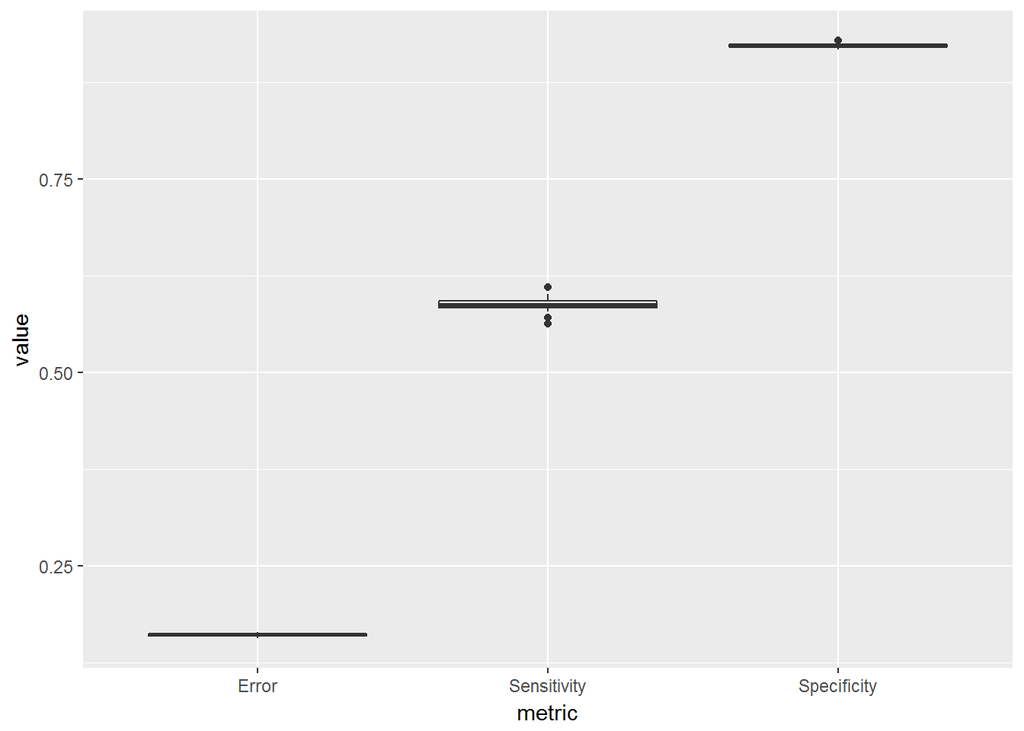

```r
#resampling for test errors, specificity, sensitivity
thres = 0.5 #thres = 0.5 gives best error rate. Tried other values of thres but not shown.
values.log = NULL
for (sim in 1:30){
train <- sample(c(T,F),nrow(data),replace = T)
log <- glm(inclvl~age+workclass+ed.num+marital+occ+sex+cgain+closs+hours+ncntry, data=data[train,], family=binomial)
log.pred <- predict(log, newdata=data[!train,], type="response")
cm <- confusionMatrix(data=factor(ifelse(log.pred>thres," >50K"," <=50K")),ref=data$inclvl[!train], positive=" >50K")
values.log <- rbind(values.log, data.frame(value=c(1-cm$overall["Accuracy"], cm$byClass["Sensitivity"], cm$byClass["Specificity"]), metric=c("Error","Sensitivity","Specificity")))
rownames(values.log) <- NULL
}


#summary of test errors
ggplot(values.log, aes(x=metric, y=value))+geom_boxplot()
```

```r
summary(subset(values.log,metric == "Error"))
```

```
##      value                metric
##  Min.   :0.1563   Error      :30
##  1st Qu.:0.1596   Sensitivity: 0
##  Median :0.1608   Specificity: 0
##  Mean   :0.1606
##  3rd Qu.:0.1619
##  Max.   :0.1643
```

```r
summary(subset(values.log,metric == "Sensitivity"))
```

```
##      value                metric
##  Min.   :0.5630   Error      : 0
##  1st Qu.:0.5836   Sensitivity:30
##  Median :0.5873   Specificity: 0
##  Mean   :0.5873
##  3rd Qu.:0.5920
##  Max.   :0.6102
```

```r
summary(subset(values.log,metric == "Specificity"))
```

```
##      value                metric
##  Min.   :0.9176   Error      : 0
##  1st Qu.:0.9212   Sensitivity: 0
##  Median :0.9220   Specificity:30
##  Mean   :0.9225
##  3rd Qu.:0.9241
##  Max.   :0.9288
```

> Running logistic regression on all predictors found that education level(ed), type of relationship(rs) and race(race) were not significant, in general. Some categories of the significant predictors might not have been, or some categories of the non-significant predictors might have been sigificant at higher significance levels. But in general, I concluded that ed, rs and race could be left out. It was not surprising that ed was not significant, since the information it provided would be captured by ed.num. And race too, which seem to be counfounded by ed.num in earlier analysis of the data. I’m not surprised that rs was non signficant too, since that seemed to be an overly granular piece of information, and I don’t think it will make big difference in income level. Marital status is a similar measure which is already in the model.

> Results using threshold of 0.5: After resampling, mean test error found is 16%, which is comparable to the author’s results. The error results are also very stable, judging from the small IQR. Sensitivity is not very good at about 58%, compared to Specificity which is 92%.

> Given the purposes of this analysis, i don’t think it is essential to have high sensitivity, so i would use the threshold of 0.5 to achieve a better error rate. For brevity, I only show the output for the optimal threshold of 0.5 based on best error rate.